# Phenotypic_data_clonal_bank

Thomas Francisco

2024-09-16

# 1 Introduction

The goal of this script is to estimate BLUP values for the phenotypic data, which will be used to evaluate genomic offset predictions. BLUP estimates allow us to generate population-level phenotypic values for each trait while accounting for covariates such as genotype for clones, tree ID when multiple measurements per tree exist, and tree size to account for age in growth-related traits.

Depending on the trait, we will select a specific period for climate data extraction. For all traits, the initial year is 1992 (the year of establishment of the clonal bank), with the following end years:  
- 2021 for leaf thickness  
- 2012 for shoot volume, stem length, spring elongation, and total open male strobili

# 2 Phenotypic data

We loaded the phenotypic traits associated with:

Growth -> Shoot volume Growth_pheno -> spring elongation Repro_pheno -> total open strobili leaf_traits -> leaf thickness

The first step is to load the functions used in the analyses.

```r
clean.MCMC <- function(x) {
  sols <- summary(x)$solutions  ## pull out relevant info from model summary
  Gcovs <- summary(x)$Gcovariances
  Rcovs <- summary(x)$Rcovariances
  fixed <- data.frame(row.names(sols), sols, row.names = NULL)  ## convert to dataframes with the row.names as the first col
  random <- data.frame(row.names(Gcovs), Gcovs, row.names = NULL)
  residual <- data.frame(row.names(Rcovs), Rcovs, row.names = NULL)
  names(fixed)[names(fixed) == "row.names.sols."] <- "variable"  ## change the columns names to variable, so they all match
  names(random)[names(random) == "row.names.Gcovs."] <- "variable"
  names(residual)[names(residual) == "row.names.Rcovs."] <- "variable"
  fixed$effect <- "fixed"  ## add ID column for type of effect (fixed, random, residual)
  random$effect <- "random"
  residual$effect <- "residual"
  modelTerms <- as.data.frame(bind_rows(fixed, random, residual))  # merge it all together
}

plot.estimates <- function(x) {
  if (class(x) != "summary.mcmc")
    x <- summary(x)
  n <- dim(x$statistics)[1]
  par(mar=c(2, 9, 4, 1))
  plot(x$statistics[,1], n:1,
       yaxt="n", ylab="",
       xlim=range(x$quantiles)*1.2,
       pch=19,
       main="Posterior means and 95% credible intervals")
  grid()
  axis(2, at=n:1, rownames(x$statistics), las=2)
  arrows(x$quantiles[,1], n:1, x$quantiles[,5], n:1, code=0)
  abline(v=0, lty=2)
}

myFun_h2Qst1 <- function(mcmc){
  out <- c(
    posterior.mode((mcmc$VCV[,2])/(rowSums(mcmc$VCV))),
    HPDinterval((mcmc$VCV[,2])/(rowSums(mcmc$VCV)))[1],
    HPDinterval((mcmc$VCV[,2])/(rowSums(mcmc$VCV)))[2],
    posterior.mode((mcmc$VCV[,2])/((mcmc$VCV[,2])+(mcmc$VCV[,3]))),
    HPDinterval((mcmc$VCV[,2])/((mcmc$VCV[,2])+(mcmc$VCV[,3])))[1],
    HPDinterval((mcmc$VCV[,2])/((mcmc$VCV[,2])+(mcmc$VCV[,3])))[2],
    posterior.mode((mcmc$VCV[,1])/(rowSums(mcmc$VCV))),
    HPDinterval((mcmc$VCV[,1])/(rowSums(mcmc$VCV)))[1],
    HPDinterval((mcmc$VCV[,1])/(rowSums(mcmc$VCV)))[2],
    posterior.mode((mcmc$VCV[,1])/(2*(mcmc$VCV[,2])+(mcmc$VCV[,1]))),
    HPDinterval((mcmc$VCV[,1])/(2*(mcmc$VCV[,2])+(mcmc$VCV[,1])))[1],
    HPDinterval((mcmc$VCV[,1])/(2*(mcmc$VCV[,2])+(mcmc$VCV[,1])))[2]
  )
  names(out) <- c("H2c_all","lo.ci.H2c_all","up.ci.H2c_all" ,"H2c","lo.ci.H2c","up.ci.H2c" ,"H2p","lo.ci.H2p","up.ci.H2p" ,"Qst","lo.ci.Qst","up.ci.Qst")
  return(out)}

# for the logit link, which is used when family=categorical
myFun_h2Qst2 <- function(mcmc){
  out <- c(
    posterior.mode((mcmc$VCV[,2])/(rowSums(mcmc$VCV)+(pi^2)/3)),
    HPDinterval((mcmc$VCV[,2])/(rowSums(mcmc$VCV)+(pi^2)/3))[1],
    HPDinterval((mcmc$VCV[,2])/(rowSums(mcmc$VCV)+(pi^2)/3))[2],
    posterior.mode((mcmc$VCV[,2])/((mcmc$VCV[,2])+(mcmc$VCV[,3])+(pi^2)/3)),
    HPDinterval((mcmc$VCV[,2])/((mcmc$VCV[,2])+(mcmc$VCV[,3])+(pi^2)/3))[1],
    HPDinterval((mcmc$VCV[,2])/((mcmc$VCV[,2])+(mcmc$VCV[,3])+(pi^2)/3))[2],
    posterior.mode(((mcmc$VCV[,1]))/(rowSums(mcmc$VCV)+(pi^2)/3)),
    HPDinterval(((mcmc$VCV[,1]))/(rowSums(mcmc$VCV)+(pi^2)/3))[1],
    HPDinterval(((mcmc$VCV[,1]))/(rowSums(mcmc$VCV)+(pi^2)/3))[2],
    posterior.mode((mcmc$VCV[,1])/(2*(mcmc$VCV[,2])+(mcmc$VCV[,1]))),
    HPDinterval((mcmc$VCV[,1])/(2*(mcmc$VCV[,2])+(mcmc$VCV[,1])))[1],
    HPDinterval((mcmc$VCV[,1])/(2*(mcmc$VCV[,2])+(mcmc$VCV[,1])))[2]
  )
  names(out) <- c("H2c_all","lo.ci.H2c_all","up.ci.H2c_all" ,"H2c","lo.ci.H2c","up.ci.H2c" ,"H2pc","lo.ci.H2pc","up.ci.H2pc" ,"Qst","lo.ci.Qst","up.ci.Qst")
  return(out)}
```

## 2.1 Data

```r
list_traits <- c("Shoot_Growth","Basal_area","Shoot_Elongation","Male_Strobili","leaf_traits")
list_names <- c("growth","growth_bis","growth_pheno","repro_pheno","leaf_traits")

for(x in 1: length(list_traits)){

  trait <- list_traits[x]
  name <- list_names[x]

  path <- paste0("C:/Users/tfrancisco/Documents/Thesis/Data/Species/Taxus_baccata/phenotypic_data/common_garden/Individual_level_data/Taxus_",trait,".xlsx")
phenotypic_data <- read_excel(path, na="NA")

assign(paste0("phenotypic_data_",name),phenotypic_data)
}
```

## 2.2 Selection of the period

For each trait, we calculated average values across years, as trait values in a given year are influenced by conditions and events from previous years. We retained the maximum number of sampling years while also maximizing the number of trees.

```r
#Growth

##Shootvol
#Identify the number of measurement per plant
phenotypic_data_growth_table <- data.frame(table(phenotypic_data_growth$Plant))

#Filter the number of measurement to keep the maximum number of individuals
phenotypic_data_growth_filtered <- phenotypic_data_growth %>%
  filter(Plant %in% phenotypic_data_growth_table$Var1[phenotypic_data_growth_table$Freq == 4])

#Mean values of the traits per plant
mean_traits_shootvol <- phenotypic_data_growth_filtered %>%
  group_by(Plant) %>%
  summarize(mean_AverageShootVolume = mean(AverageShootVolume.mm3, na.rm = TRUE),
            mean_StemLength = mean(StemLength.cm, na.rm = TRUE))

mean_traits_shootvol_merge <- merge(mean_traits_shootvol,phenotypic_data_growth,"Plant")

#Keep only one value per plant (ex: 2012, it's not only the values of 2012)
mean_traits_growth_f <- mean_traits_shootvol_merge %>%
  filter(Year == 2012)

##Basal area
mean_traits_growth_bis_f <- data.frame(phenotypic_data_growth_bis) %>%
  filter(across(c(SumAB.2021.cm2, StemLength.cm), ~ !is.na(.)))
```

```r
# Growth phenology

##Spring elong
#identify the number of measurement per plant
phenotypic_data_phenology_table <- data.frame(table(phenotypic_data_growth_pheno$Plant))

#filter the number of measurement to keep the maximum number of individuals
phenotypic_data_pheno_filtered <- phenotypic_data_growth_pheno %>%
  filter(Plant %in% phenotypic_data_phenology_table$Var1[phenotypic_data_phenology_table$Freq == 3])

#mean values of the traits per plant
mean_traits_pheno <- phenotypic_data_pheno_filtered %>%
  group_by(Plant) %>%
  summarize(mean_springelong = mean(ProportionSpringElongation, na.rm = TRUE))

mean_traits_pheno_merge <- merge(mean_traits_pheno,phenotypic_data_growth_pheno,"Plant")

#keep only one value per plant (ex: 2012, it's not only the values of 2012)
mean_traits_growth_pheno_f <- mean_traits_pheno_merge %>%
  filter(Year == 2012)
```

```r
# Reproductive phenology

##Reproduction
#identify the number of measurement per plant
phenotypic_data_repro_table <- data.frame(table(phenotypic_data_repro_pheno$Plant))

#filter the number of measurement to keep the maximum number of individuals
phenotypic_data_repro_filtered <- phenotypic_data_repro_pheno %>%
  filter(Plant %in% phenotypic_data_repro_table$Var1[phenotypic_data_repro_table$Freq == 3])

#mean values of the traits per plant
mean_traits_repro <- phenotypic_data_repro_filtered %>%
  group_by(Plant) %>%
  summarize(mean_proportion_open = mean(Proportion_total_open, na.rm = TRUE))

mean_traits_repro_merge <- merge(mean_traits_repro,phenotypic_data_repro_pheno,"Plant")

#keep only one value per plant (ex: 2012, it's not only the values of 2012)
mean_traits_repro_pheno_f <- mean_traits_repro_merge %>%
  filter(Year == 2012)
```

```r
#Leaf_traits
phenotypic_data_leaftrait_table <- data.frame(table(phenotypic_data_leaf_traits$Plant))
#table(phenotypic_data_leaftrait_table$Freq)#we retained 4

#filter the number of measurement to keep the maximum number of individuals
phenotypic_data_leaftrait_filtered <- phenotypic_data_leaf_traits %>%
  filter(Plant %in% phenotypic_data_leaftrait_table$Var1[phenotypic_data_leaftrait_table$Freq == 4])

#mean values of the traits per plant
mean_traits_leaftraits <- phenotypic_data_leaftrait_filtered %>%
  group_by(Plant) %>%
  summarize(mean_StomDens = mean(StomDens.mm2, na.rm = TRUE),
            mean_leafthickness = mean(LeafThickness.mm, na.rm = TRUE),
            mean_LMA = mean(LMA.gm2,na.rm=T),
            mean_D13C = mean(D13C,na.rm=T))

mean_traits_leaftraits_merge <- merge(mean_traits_leaftraits,phenotypic_data_leaf_traits[,c(1:5)],"Plant")

#keep only one value per plant (ex: 2012, it's not only the values of 2012)
mean_traits_leaftraits_f <- mean_traits_leaftraits_merge %>%
  filter(Year == "Y2021")
```

## 2.3 Selection of the populations with enought trees

We also checked the number of measured individuals per population, retaining only populations with more than two individuals.

```r
table(mean_traits_growth_f$Population)
```

```
##
##       ACEBEDO         AGRES         ALCOY       ARAGUES      ASPONTES
##             2            16             5            16             5
##       BARRACO       BEGONTE  BOCAHUERGANO      CANENCIA     CERVANTES
##            10             6             4             8            16
##         FANLO       FOLGOSO         JERTE       LASENIA      MONTAGUT
##             9            14             6             2             8
##    MONTSERRAT     NUNOMORAL   PUEBLALILLO       QUESADA     RASCAFRIA
##             5            26             5             3            16
##      RASQUERA SALES_LLIERCA         SILES         TORLA    VILLABLINO
##             5             8             9            33             5
##       VIMBODI
##             5
```

```r
#We removed the ACEBDO, LASENIA

table(mean_traits_growth_pheno_f$Population)
```

```
##
##       ACEBEDO         AGRES         ALCOY       ARAGUES      ASPONTES
##             2             8             2            16             4
##       BARRACO       BEGONTE  BOCAHUERGANO      CANENCIA     CERVANTES
##            10             6             4             8            16
##         FANLO       FOLGOSO         JERTE       LASENIA      MONTAGUT
##             9            14             6             2             8
##    MONTSERRAT     NUNOMORAL   PUEBLALILLO       QUESADA     RASCAFRIA
##             5            14             4             2            16
##      RASQUERA SALES_LLIERCA         SILES         TORLA    VILLABLINO
##             3             8             3            14             4
##       VIMBODI
##             5
```

```r
#We removed the ACEBDO, ALCOY, LASENIA Quesada pop

table(mean_traits_repro_pheno_f$Population)
```

```
##
##         AGRES       ARAGUES       BARRACO  BOCAHUERGANO      CANENCIA
##             3             9             5             1             5
##         FANLO       FOLGOSO         JERTE       LASENIA      MONTAGUT
##             4             9             2             2             3
##    MONTSERRAT     NUNOMORAL   PUEBLALILLO     RASCAFRIA      RASQUERA
##             3             5             2             8             2
## SALES_LLIERCA         TORLA       VIMBODI
##             4             6             3
```

```r
#We removed the BOCAHUERGANO, JERTE, LASENIA,PUEBLALILLO and RASQUERA

table(mean_traits_leaftraits_f$Population)
```

```
##
##       ACEBEDO         AGRES         ALCOY       ARAGUES      ASPONTES
##             2             8             2            16             4
##       BARRACO       BEGONTE  BOCAHUERGANO      CANENCIA     CERVANTES
##            10             6             4             8            14
##         FANLO       FOLGOSO         JERTE       LASENIA      MONTAGUT
##             8            14             6             2             8
##    MONTSERRAT     NUNOMORAL  PUEBLA_LILLO       QUESADA     RASCAFRIA
##             5            14             4             2            15
##      RASQUERA SALES_LLIERCA         SILES         TORLA   VILLLABLINO
##             3             8             3            15             4
##       VIMBODI
##             5
```

```r
#we can remove: ACEBEDO, ALCOY, LASENIA, and QUESADA
```

## 2.4 Graphical visualization

To select the type of distribution used in the GLMM models, we investigated the shape of the data distribution for each trait.

```r
list_traits <- c("growth","growth_bis","growth_pheno","repro_pheno","leaftraits")
for(x in 1: length(list_traits)){

  name <- list_traits[x]
  df <- get(paste0("mean_traits_",name,"_f"))

df$Population<- as.factor(df$Population)
df$Plant <- as.factor(df$Plant)
df$Genet <- as.factor(df$Genet)

assign(paste0("phenotypic_data_",name),df)
}
```

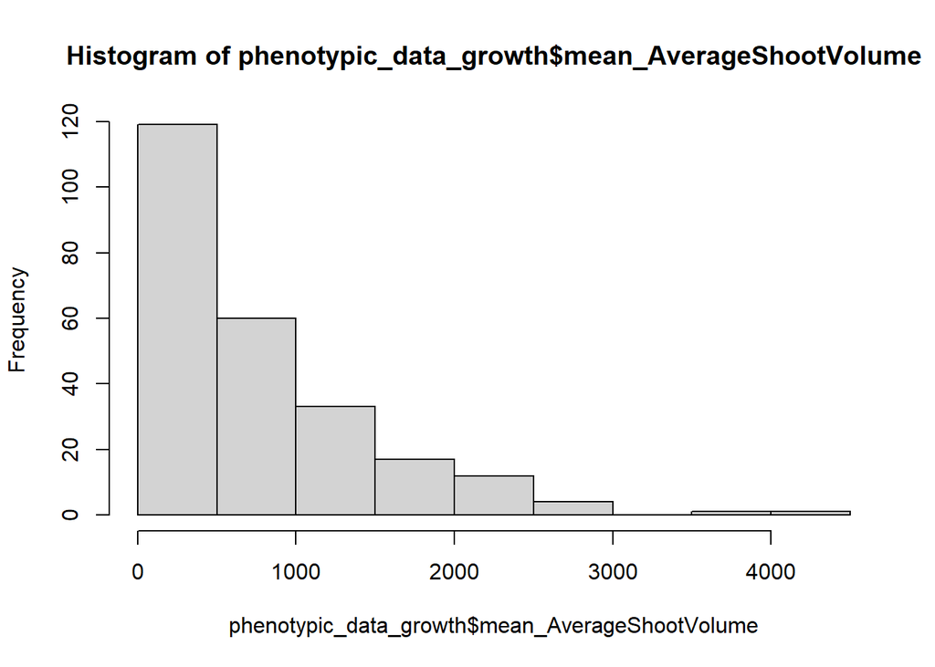

```r
hist(phenotypic_data_growth$mean_AverageShootVolume)
```

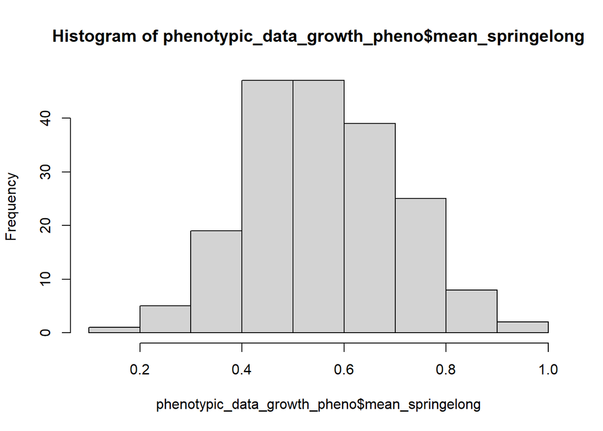

```r
#hist(phenotypic_data_growth_bis$SumAB.2021.cm2)
hist(phenotypic_data_growth_pheno$mean_springelong)
```

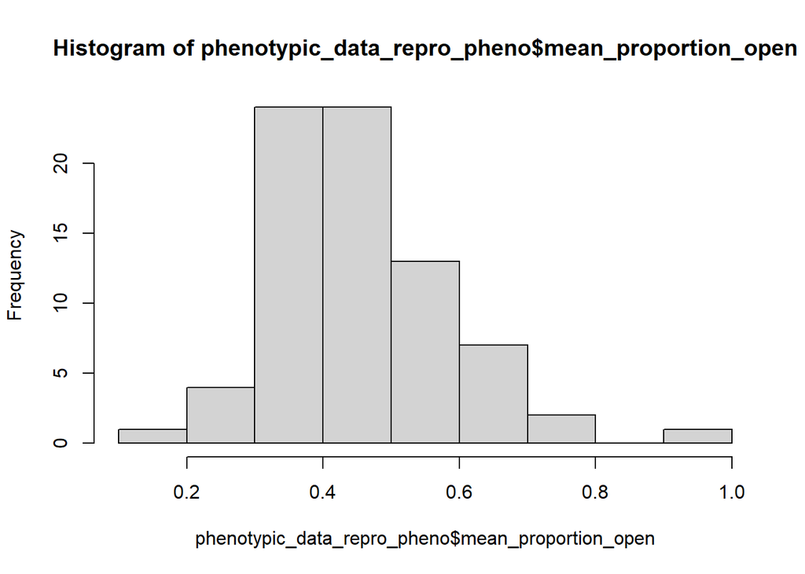

```r
hist(phenotypic_data_repro_pheno$mean_proportion_open)
```

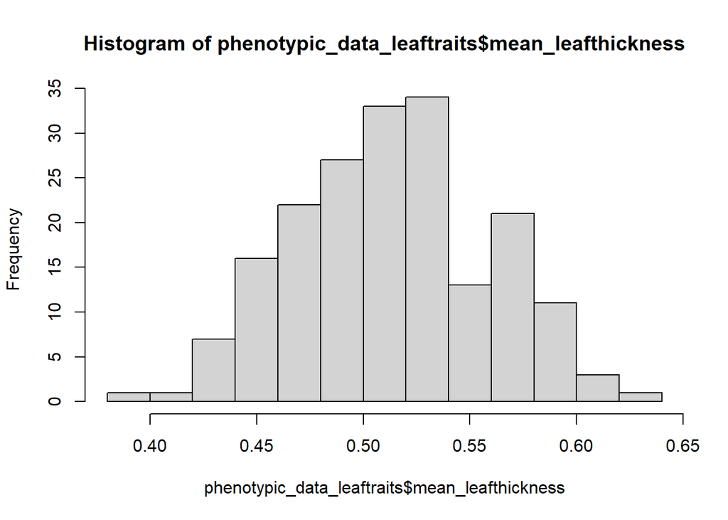

```r
#hist(phenotypic_data_leaftraits$mean_StomDens)
hist(phenotypic_data_leaftraits$mean_leafthickness)
```

```r
#hist(phenotypic_data_leaftraits$mean_LMA)
#hist(phenotypic_data_leaftraits$mean_D13C)
```

# 3 MCMC GLMM models

## 3.1 Trait related to growth

### 3.1.1 Shoot Volume

For growth traits, as trees in the clonal bank vary in age, we used stem length as a covariate to account for differences in shoot volume associated with tree age.

```r
load("C:/Users/tfrancisco/Documents/Thesis/Results/species/taxus/phenotypic_data/mean_years/ShootVol_model_wo_plantID.rda")
growth_model_wo_plantID <- ShootVol_model_wo_plantID
```

New version by putting mean_StemLength as a fixed effect to calculate the slope and not and individual effect of each individuals (too much parameters)

## 3.2 Trait related to growth phenology

### 3.2.1 Spring elongation

```r
load("C:/Users/tfrancisco/Documents/Thesis/Results/species/taxus/phenotypic_data/mean_years/springelong_model_wo_plantID.rda")
growth_pheno_model_wo_plantID <- springelong_model_wo_plantID
```

## 3.3 Trait related to reproductive phenology

### 3.3.1 Proportion open strobili

```r
load("C:/Users/tfrancisco/Documents/Thesis/Results/species/taxus/phenotypic_data/mean_years/openstrob_model_wo_plantID.rda")
repro_pheno_model_wo_plantID <- openstrob_model_wo_plantID
```

## 3.4 Water statues

### 3.4.1 Leaf thickness

```r
load("C:/Users/tfrancisco/Documents/Thesis/Results/species/taxus/phenotypic_data/mean_years/leafthickness_model_wo_plantID.rda")
leafthickness_model_wo_plantID <-leafthickness_model_wo_plantID
```

# 4 Evaluation of the models

To evaluate the performance of the models, we investigated several aspects:

## 4.1 Autocorrelation within MCMC

First, we checked the autocorrelation between values within the same MCMC chain to ensure that our thinning interval was sufficient.

```r
list_name<- c("Population","Genet")
list_model <- c("growth","growth_pheno","repro_pheno","leafthickness")#"growth_bis","LMA","StomDens","D13C"

for(i in 1:length(list_model)){

  model_pheno <- get(paste0(list_model[i],"_model_wo_plantID"))
  name_pheno <- list_model[i]
for(x in 1:2){
  name <- list_name[x]

  acf_list <- lapply(model_pheno, function(model) {
  #Extract the MCMC samples for the random effects of provenance
  mcmc_samples <- mcmc(model$VCV[, name])
  #Calculate ACF
  acf_values <- acf(as.numeric(mcmc_samples), plot = FALSE)  #Convert to numeric if needed
  return(acf_values)
})

  # Plot the first ACF
plot(acf_list[[1]], main=paste0("Autocorrelation for ",name," Random Effect ",name_pheno), col="black", lwd=2)

colors <- c("red", "blue", "green")  #Colors for the additional chains
for (i in 2:length(acf_list)) {
  lines(acf_list[[i]]$lag, acf_list[[i]]$acf, col=colors[i-1], lwd=2)
}
#Add a legend to distinguish between the chains
legend("topright", legend=paste("Chain", 1:length(model_pheno)), col=c("black", colors), lwd=2)

plot
#Save
png(paste0("C:/Users/tfrancisco/Documents/Thesis/Results/species/taxus/phenotypic_data/figures_wo_plantID/checkmodel/autocorrelation/Autocorrelation_period_",name,"_",name_pheno,".png"));plot(acf_list[[1]], main=paste0("Autocorrelation for ",name," Random Effect ",name_pheno), col="black", lwd=2)
colors <- c("red", "blue", "green")
for (i in 2:length(acf_list)) {
  lines(acf_list[[i]]$lag, acf_list[[i]]$acf, col=colors[i-1], lwd=2)
}
legend("topright", legend=paste("Chain", 1:length(model_pheno)), col=c("black", colors), lwd=2);dev.off()
  }
}
```

[output not shown]

## 4.2 Chains convergence

Next, we ensured that the MCMC chains were converging.

```r
for(i in 1:length(list_model)){
model_pheno <- get(paste0(list_model[i],"_model_wo_plantID"))
  name_pheno <- list_model[i]

for(x in 1: length(list_name)){

  name <- list_name[x]

  #Create MCMC lists for overall random effects (aggregated)
mcmc_list <- mcmc.list(lapply(model_pheno, function(model) {
  #Aggregate random effects for provenance
  mcmc(model$VCV[, name])
}))

par(mfrow=c(2,1), mar=c(4,4,2,1))  #Two plots: one for provenance, one for plant ID

#Plot trace plot for overall provenance random effect
plot(mcmc_list, auto.layout=FALSE, main=paste0("Trace Plot for Overall ",name," Random Effect ",name_pheno), col=c("red", "blue", "green", "black"))

#Save
png(paste0("C:/Users/tfrancisco/Documents/Thesis/Results/species/taxus/phenotypic_data/figures_wo_plantID/checkmodel/convergence/MCMC_period_",name,"_",name_pheno,".png"));par(mfrow=c(2,1), mar=c(4,4,2,1))
plot(mcmc_list, auto.layout=FALSE, main=paste0("Trace Plot for Overall ",name," Random Effect ",name_pheno), col=c("red", "blue", "green", "black"));dev.off()
  }
}
```

[output not shown]

```r
list_model <- c("growth","growth_pheno","repro_pheno","leafthickness")#"growth_bis","LMA","StomDens","D13C"

gelman_rubin_results <- list()

for(i in 1:length(list_model)){

  #Get the model object
  model_pheno <- get(paste0(list_model[i], "_model_wo_plantID"))
  name_pheno <- list_model[i]

  #Combine the MCMC chains into a single mcmc.list
  chaine_mc <- lapply(model_pheno, function(m) m$Sol)
  chaine_mc <- do.call(mcmc.list, chaine_mc)

  #Gelman-Rubin (GR) criterion to assess convergence across MCMC chains
  GRcriterion_index <- gelman.diag(chaine_mc)

  #Store the summary of the GR criterion in the list
  gelman_rubin_results[[name_pheno]] <- list(
    mpsrf = GRcriterion_index$mpsrf
  )
}
gelman_rubin_results
```

```
## $growth
## $growth$mpsrf
## [1] 1.047963
##
##
## $growth_pheno
## $growth_pheno$mpsrf
## [1] 1.01642
##
##
## $repro_pheno
## $repro_pheno$mpsrf
## [1] 1.008652
##
##
## $leafthickness
## $leafthickness$mpsrf
## [1] 1.018937
```

We can see that the Gelman-Rubin values are below 1.1, which is the defined threshold for convergence.

## 4.3 Similarity of the posterior distribution across chains

We also examined the posterior distributions to assess the convergence of the MCMC results.

```r
for(i in 1:length(list_model)){
  model_pheno <- get(paste0(list_model[i],"_model_wo_plantID"))
  name_pheno <- list_model[i]

for(x in 1:length(list_name)){

  name <-list_name[x]

  density_list <- lapply(model_pheno, function(model) {
  #Extract the MCMC samples for the random effects of provenance
  mcmc_samples <- as.numeric(mcmc(model$VCV[, name]))
  #Calculate density
  density_values <- density(mcmc_samples)
  return(density_values)
})
  #Limit of the plot
  max_density_value <- max(sapply(density_list, function(d) max(d$y)))

  #Plot the first density
plot(density_list[[1]], main=paste0("Posterior distribution of the ",name," Random Effect value ",name_pheno), col="black", lwd=2, xlab="Value", ylab="Density",ylim=c(0, max_density_value * 1.02))

#Overlay the remaining densities
colors <- c("red", "blue", "green")  #Colors for the additional chains
for (i in 2:length(density_list)) {
  lines(density_list[[i]], col=colors[i-1], lwd=2)
}

#Add a legend to distinguish between the chains
legend("topright", legend=paste("Chain", 1:length(model_pheno)), col=c("black", colors), lwd=2)

#Save
png(paste0("C:/Users/tfrancisco/Documents/Thesis/Results/species/taxus/phenotypic_data/figures_wo_plantID/postdistrib/Posterior_distrib_period_",name,"_",name_pheno,".png"));plot(density_list[[1]], main=paste0("Posterior distribution of the ",name," Random Effect value ",name_pheno), col="black", lwd=2, xlab="Value", ylab="Density",ylim=c(0, max_density_value * 1.02))
colors <- c("red", "blue", "green")  # Colors for the additional chains
for (i in 2:length(density_list)) {
  lines(density_list[[i]], col=colors[i-1], lwd=2)
}
legend("topright", legend=paste("Chain", 1:length(model_pheno)), col=c("black", colors), lwd=2);dev.off()
  }
}
```

[output not shown]

# 5 Blups values

Finally, we extracted the BLUP values from the models.

To calculate the BLUPs, we used the mean BLUP value across the four MCMC runs.

```r
#list_model <- c("growth","growth_bis","growth_pheno","repro_pheno","leafthickness","LMA","StomDens","D13C")
list_model <- c("growth","growth_pheno","repro_pheno","leafthickness")#"growth_bis","LMA","StomDens"

for(i in 1:length(list_model)){
  model_pheno <- get(paste0(list_model[i],"_model_wo_plantID"))
  name_pheno <- list_model[i]

#BLUPs values
for(x in 1:4){

  model <- model_pheno[[x]] #Extract the chains from the model
  blups<-data.frame(posterior.mode(model$Sol))
  assign(paste0("blups_",name_pheno,"_",x),blups)
  }
}

for(i in 1:length(list_model)){

  name_pheno <- list_model[i]

  MC1 <- get(paste0("blups_",name_pheno,"_1"))
  MC2 <- get(paste0("blups_",name_pheno,"_2"))
  MC3 <- get(paste0("blups_",name_pheno,"_3"))
  MC4 <- get(paste0("blups_",name_pheno,"_4"))

  Blups_df <- data.frame(MC1,MC2,MC3,MC4)
  Blups_df$mean_blup <- rowMeans(Blups_df)

write_xlsx(data.frame(row.names(Blups_df),Blups_df[,c(5)]),paste0("C:/Users/tfrancisco/Documents/Thesis/Results/species/taxus/phenotypic_data/BLUPs_mean/Blups_",name_pheno,"final_period.xlsx"))
}
```

# 6 Draft

```r
df_growth <- read_excel("C:/Users/tfrancisco/Documents/Thesis/Results/species/taxus/phenotypic_data/BLUPs_mean/Blups_growthfinal_period.xlsx")

df_growth <- df_growth[c(2:27),]

df_growth_V2 <- read_excel("C:/Users/tfrancisco/Documents/Thesis/Results/species/taxus/phenotypic_data/BLUPs_mean/Blups_growth_V2final_period.xlsx")
df_growth_V2 <- df_growth_V2[c(2:27),]

cor(df_growth$Blups_df...c.5..,df_growth_V2$Blups_df...c.5..)
```

```
## [1] 0.3034145
```

## 6.1 Mean value of CFI after accounting for uncertainty in trait values

## 6.2 Phenotypic values not using BLUPs (not using population as a random factor), as suggested by Reviewer 2

### 6.2.1 Trait related to growth

#### 6.2.1.1 Shoot Volume

For growth traits, as trees in the clonal bank vary in age, we used stem length as a covariate to account for differences in shoot volume associated with tree age.

Reduce

Fixed effect

## 6.3 Trait related to growth phenology

### 6.3.1 Spring elongation

## 6.4 Trait related to reproductive phenology

### 6.4.1 Proportion open strobili

## 6.5 Water statues

### 6.5.1 Leaf thickness

Traits:

Basal area

LMA

StomDens

D13C